# Modeling_ver5_Rmd

티타임

2023-12-25

## 0. 서론

Breast Cancer Wisconsin(Diagnostic) Data set은 주사기로 종양에서 세포를 흡인해서 현미경으로 세포를 관찰해 그 특징들을 mean, se, worst로 정리한 데이터 셋입니다. 저희는 이 데이터를 통해서 양성 종양과 악성 종양을 정확하게 구분할 수 있는 모델을 구현하고자 합니다. 이를 통해 오진율을 줄이는 것을 목표로 잡았습니다.

### 0-1. 패키지 불러오기

```r
# plotting and reshaping data
library(tidyverse)
library(GGally)
library(reshape)

# Correlation
library(corrplot)

# Confusion Matrix
library(caret)

# ROC Curve
library(ROCR)

# Model
library(rpart)
library(rpart.plot)
library(randomForest)

# Plot combine
library(gridExtra)
```

## 1. 데이터 불러오기 및 확인

```r
# 데이터 불러오기
breast_cancer_data <- read.csv("../data/breast_cancer.csv")
```

```r
breast_cancer_data = subset(breast_cancer_data, select=c(-33))

colnames(breast_cancer_data)
```

```
##  [1] "id"                      "diagnosis"
##  [3] "radius_mean"             "texture_mean"
##  [5] "perimeter_mean"          "area_mean"
##  [7] "smoothness_mean"         "compactness_mean"
##  [9] "concavity_mean"          "concave.points_mean"
## [11] "symmetry_mean"           "fractal_dimension_mean"
## [13] "radius_se"               "texture_se"
## [15] "perimeter_se"            "area_se"
## [17] "smoothness_se"           "compactness_se"
## [19] "concavity_se"            "concave.points_se"
## [21] "symmetry_se"             "fractal_dimension_se"
## [23] "radius_worst"            "texture_worst"
## [25] "perimeter_worst"         "area_worst"
## [27] "smoothness_worst"        "compactness_worst"
## [29] "concavity_worst"         "concave.points_worst"
## [31] "symmetry_worst"          "fractal_dimension_worst"
```

### 1-2. diagnosis 변수를 factor로 변환

```r
# diagnosis를 char에서 factor로 변환
breast_cancer_data$diagnosis = as.factor(breast_cancer_data$diagnosis)
```

```r
data_selected = breast_cancer_data %>% select(!contains(c("perimeter", "area", "concavity", "concave.points")))


colnames(data_selected) # id와 diagnosis를 제외한 나머지가 선택된 변수
```

```
##  [1] "id"                      "diagnosis"
##  [3] "radius_mean"             "texture_mean"
##  [5] "smoothness_mean"         "compactness_mean"
##  [7] "symmetry_mean"           "fractal_dimension_mean"
##  [9] "radius_se"               "texture_se"
## [11] "smoothness_se"           "compactness_se"
## [13] "symmetry_se"             "fractal_dimension_se"
## [15] "radius_worst"            "texture_worst"
## [17] "smoothness_worst"        "compactness_worst"
## [19] "symmetry_worst"          "fractal_dimension_worst"
```

## 3. Modeling

먼저 569EA의 데이터를 train(70%), validation(30%)로 나눠주겠습니다.

- train_index: 전체 데이터 중 70%를 샘플링한 데이터
- breast_cancer_train: train 데이터
- breast_cancer_valid: validation 데이터

```r
set.seed(123)

T_count = nrow(breast_cancer_data)

# 고정된 인덱스 생성
fixed_index = sample(1:T_count)

# train과 valid의 비율을 7:3 으로 설정
train_ratio = 0.7
train_rows = round(T_count * train_ratio)

# 고정된 인덱스에서 train 데이터의 인덱스 선택
train_index = fixed_index[1:train_rows]

# train과 valid로 데이터 나누기.
breast_cancer_train = data_selected[train_index,]
breast_cancer_valid = data_selected[-train_index,]

train_count = train_rows
valid_count = T_count - train_count

cat("train data: ", train_count, "EA\n", "validation data: ", valid_count, "EA")
```

```
## train data:  398 EA
##  validation data:  171 EA
```

### 4-2. Scorecard

```r
# valdation 데이터 이용
selected_data <- breast_cancer_valid %>%
  select(id, diagnosis, radius_mean, texture_mean, smoothness_mean, compactness_mean,
         symmetry_mean,radius_se, texture_se, fractal_dimension_se)

head(selected_data)
```

```
##          id diagnosis radius_mean texture_mean smoothness_mean compactness_mean
## 1    842302         M       17.99        10.38         0.11840          0.27760
## 2    842517         M       20.57        17.77         0.08474          0.07864
## 9    844981         M       13.00        21.82         0.12730          0.19320
## 15 84667401         M       13.73        22.61         0.11310          0.22930
## 17   848406         M       14.68        20.13         0.09867          0.07200
## 18 84862001         M       16.13        20.68         0.11700          0.20220
##    symmetry_mean radius_se texture_se fractal_dimension_se
## 1         0.2419    1.0950     0.9053             0.006193
## 2         0.1812    0.5435     0.7339             0.003532
## 9         0.2350    0.3063     1.0020             0.003749
## 15        0.2069    0.2121     1.1690             0.008093
## 17        0.1586    0.4727     1.2400             0.002085
## 18        0.2164    0.5692     1.0730             0.004142
```

```r
# 최종 변수 리스트
var_list <- c('radius_mean', 'texture_mean', 'smoothness_mean', 'compactness_mean', 'symmetry_mean', 'radius_se', 'texture_se', 'fractal_dimension_se')

# 분포 기반 범주화 및 범주 범위 출력
for (var in var_list) {
  # 범주화
  breast_cancer_train <- breast_cancer_train %>%
    mutate(!!paste0(var, "_cat") := cut(!!sym(var), breaks=quantile(!!sym(var), probs=seq(0, 1, by=0.25)), include.lowest=TRUE))

  # 범주 범위 출력
  cat(paste("Variable:", var, "\n"))
  print(summary(as.factor(breast_cancer_train[[paste0(var, "_cat")]])))
}
```

```
## Variable: radius_mean
## [6.98,11.6] (11.6,13.2] (13.2,15.4] (15.4,27.2]
##         100          99          99         100
## Variable: texture_mean
## [10.7,16.2] (16.2,18.9] (18.9,21.8] (21.8,33.6]
##         100         100          98         100
## Variable: smoothness_mean
## [0.0526,0.085] (0.085,0.0946] (0.0946,0.105]  (0.105,0.163]
##            100            101             97            100
## Variable: compactness_mean
## [0.0194,0.0631] (0.0631,0.0896]   (0.0896,0.13]    (0.13,0.287]
##             100              99              99             100
## Variable: symmetry_mean
## [0.117,0.163] (0.163,0.179] (0.179,0.195] (0.195,0.304]
##           100            99           100            99
## Variable: radius_se
## [0.112,0.232] (0.232,0.316] (0.316,0.468]  (0.468,1.51]
##           100            99            99           100
## Variable: texture_se
## [0.36,0.856] (0.856,1.14]  (1.14,1.48]  (1.48,3.65]
##          100           99           99          100
## Variable: fractal_dimension_se
## [0.000895,0.00222]  (0.00222,0.00313]   (0.00313,0.0045]    (0.0045,0.0298]
##                100                 99                 99                100
```

```r
# 각 변수에 대해 주어진 범위에 따라 점수를 부여
score_03_data <- selected_data %>%
  mutate(radius_mean_score = ifelse(radius_mean <= 10, 9.5,
                                    ifelse(radius_mean <= 13, 12.7,
                                           ifelse(radius_mean <= 16, 14.6, 21.8))),

         texture_mean_score = ifelse(texture_mean <= 16, 5.8,
                                     ifelse(texture_mean <= 19, 7.6,
                                            ifelse(texture_mean <= 22, 8.8, 12.0))),

         smoothness_mean_score = ifelse(smoothness_mean <= 0.08, 5.4,
                                        ifelse(smoothness_mean <= 0.09, 7.1,
                                               ifelse(smoothness_mean <= 0.12, 7.9, 10.6))),

         compactness_mean_score = ifelse(compactness_mean <= 0.06, 1.1,
                                         ifelse(compactness_mean <= 0.09, 2.1,
                                                ifelse(compactness_mean <= 16, 3.0, 5.8))),

         symmetry_mean_score = ifelse(symmetry_mean <= 0.16, 2.5,
                                      ifelse(symmetry_mean <= 0.18, 3.1,
                                             ifelse(symmetry_mean <= 0.20, 3.4, 4.5))),

         radius_se_score = ifelse(radius_se <= 0.22, 0.8,
                                  ifelse(radius_se <= 0.33, 1.2,
                                         ifelse(radius_se <= 0.44, 1.8, 4.6))),

         texture_se_score = ifelse(texture_se <= 0.90, -0.8,
                                   ifelse(texture_se <= 1.20, -1.4,
                                          ifelse(texture_se <= 1.50, -1.9, -3.7))),

         fractal_dimension_se_score = ifelse(fractal_dimension_se <= 0.002, -0.5,
                                             ifelse(fractal_dimension_se <= 0.003, -1.0,
                                                    ifelse(fractal_dimension_se <= 0.004, -1.4, -6.4))))


# _score로 끝나는 모든 변수들의 합을 계산하여 score라는 새로운 열을 생성
score_03_vars <- grep("_score$", names(score_03_data), value = TRUE)

score_03_data <- score_03_data %>% mutate(score = rowSums(.[score_03_vars]))
```

```r
group_B <- score_03_data$score[score_03_data$diagnosis == "B"]
group_M <- score_03_data$score[score_03_data$diagnosis == "M"]

# KS 통계량 계산
ks_result_03 <- ks.test(group_B, group_M)

# KS 통계량 출력
print(ks_result_03$statistic)
```

```
##         D
## 0.8256919
```

[figure not shown]

```r
# 누적 B/M 구성비 분포 그래프 그리기
ggplot() +
  stat_ecdf(data = data.frame(score = group_B, group = "B"), aes(score, colour = group)) +
  stat_ecdf(data = data.frame(score = group_M, group = "M"), aes(score, colour = group)) +
  labs(x = "Score", y = "Cumulative Proportion",
       title = "Cumulative Distribution Plot for Score",
       subtitle = "Blue: Group B, Red: Group M")
```

```r
# 'B'와 'M' 진단 그룹의 실제 라벨 생성
actual <- ifelse(score_03_data$diagnosis == "B", 0, 1)

# 예측 객체 생성
pred <- prediction(score_03_data$score, actual)

# ROC 곡선 계산
roc_obj <- performance(pred, "tpr", "fpr")

# AUROC 값 계산
auc_obj <- performance(pred, "auc")

# AUROC 값 출력
print(auc_obj@y.values[[1]])
```

```
## [1] 0.9534526
```

=================== 이후 update 버전 =============================

## 5. Scoring model 적용

### AUROC 이용한 score 임계치 구하기

ROC 곡선은 여러 임계값에서의 진짜 양성률 (True Positive Rate, TPR)과 거짓 양성률 (False Positive Rate, FPR)을 나타냅니다. 이 곡선 아래의 면적이 AUROC이며, 이 값이 1에 가까울수록 모델의 성능이 좋다고 판단합니다.

```r
# ROCR 패키지 로드
library(ROCR)

# 예측 객체 생성
pred <- prediction(score_03_data$score, actual)

# 최적의 임계값 찾기
perf <- performance(pred, "sens", "spec")
decision.values <- data.frame(cut = perf@alpha.values[[1]],
                              sensitivity = perf@x.values[[1]],
                              specificity = perf@y.values[[1]])
optimal.cut <- decision.values[which.max(decision.values$sensitivity + decision.values$specificity), "cut"]

# 최적의 임계값 출력
print(optimal.cut)
```

```
## [1] 35
```

ROC 곡선에서 최적의 임계값을 찾는 과정을 진행하였고 **score의 임계값은 35**

### 점수 계산

입력되는 환자의 데이터에 대해서 각 변수들에 대한 점수를 계산  
각 변수별로 계산된 점수의 총점에 따라 진단을 하는 함수를 작성

```r
# 함수 생성
calculate_score_and_diagnose <- function(data) {
  data <- data %>%
    mutate(radius_mean_score = ifelse(radius_mean <= 10, 9.5,
                                       ifelse(radius_mean <= 13, 12.7,
                                              ifelse(radius_mean <= 16, 14.6, 21.8))),
           texture_mean_score = ifelse(texture_mean <= 16, 5.8,
                                       ifelse(texture_mean <= 19, 7.6,
                                              ifelse(texture_mean <= 22, 8.8, 12.0))),
           smoothness_mean_score = ifelse(smoothness_mean <= 0.08, 5.4,
                                          ifelse(smoothness_mean <= 0.09, 7.1,
                                                 ifelse(smoothness_mean <= 0.12, 7.9, 10.6))),
           compactness_mean_score = ifelse(compactness_mean <= 0.06, 1.1,
                                           ifelse(compactness_mean <= 0.09, 2.1,
                                                  ifelse(compactness_mean <= 16, 3.0, 5.8))),
           symmetry_mean_score = ifelse(symmetry_mean <= 0.16, 2.5,
                                        ifelse(symmetry_mean <= 0.18, 3.1,
                                               ifelse(symmetry_mean <= 0.20, 3.4, 4.5))),
           radius_se_score = ifelse(radius_se <= 0.22, 0.8,
                                    ifelse(radius_se <= 0.33, 1.2,
                                           ifelse(radius_se <= 0.44, 1.8, 4.6))),
           texture_se_score = ifelse(texture_se <= 0.90, -0.8,
                                     ifelse(texture_se <= 1.20, -1.4,
                                            ifelse(texture_se <= 1.50, -1.9, -3.7))),
           fractal_dimension_se_score = ifelse(fractal_dimension_se <= 0.002, -0.5,
                                               ifelse(fractal_dimension_se <= 0.003, -1.0,
                                                      ifelse(fractal_dimension_se <= 0.004, -1.4, -6.4))))

  score_vars <- grep("_score$", names(data), value = TRUE)

  data <- data %>% mutate(score = rowSums(.[score_vars]))

  data <- data %>% mutate(diagnosis = ifelse(score > 35, "M", "B"))

  return(data)
}
```

### 적용할 데이터 준비

평가데이터에서 악성환자와 양성환자 데이터 확보

```r
# valdation 데이터 이용
sample_data <- breast_cancer_valid %>%
  select(id, diagnosis, radius_mean, texture_mean, smoothness_mean, compactness_mean,
         symmetry_mean,radius_se, texture_se, fractal_dimension_se)

# diagnosis가 'M'인 첫 번째 행 선택
M_data <- selected_data %>%
  filter(diagnosis == 'M') %>%
  slice(1)

# diagnosis가 'B'인 첫 번째 행 선택
B_data <- selected_data %>%
  filter(diagnosis == 'B') %>%
  slice(1)
```

```r
M_data # Malignant(악성=M)인 환자데이터
```

```
##       id diagnosis radius_mean texture_mean smoothness_mean compactness_mean
## 1 842302         M       17.99        10.38          0.1184           0.2776
##   symmetry_mean radius_se texture_se fractal_dimension_se
## 1        0.2419     1.095     0.9053             0.006193
```

```r
B_data # Benign(양성=B)인 환자데이터
```

```
##        id diagnosis radius_mean texture_mean smoothness_mean compactness_mean
## 1 8510653         B       13.08        15.71          0.1075            0.127
##   symmetry_mean radius_se texture_se fractal_dimension_se
## 1        0.1967    0.1852     0.7477             0.002425
```

### 스코어링 모형 적용

Benign(양성)인 환자와 Malignant(악성)인 환자에 대해서 각각 스코어링 모형에 적용

#### Benign(양성)인 환자데이터

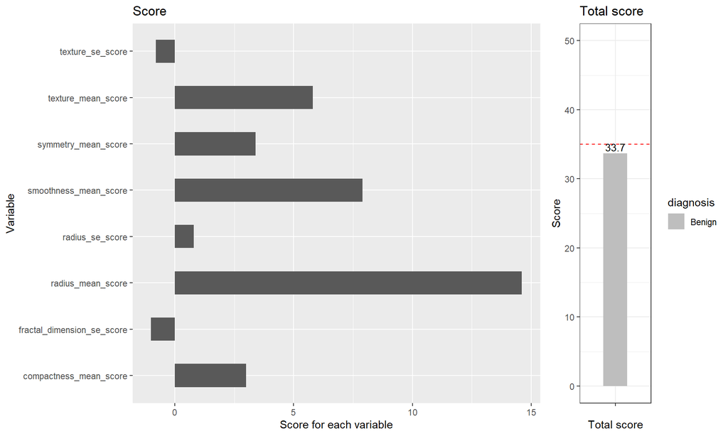

```r
# B_data # Benign(양성=B)인 환자데이터
use_data = B_data

result <- calculate_score_and_diagnose(use_data)

# 첫번째 그래프
# "_score"로 끝나는 변수만 선택합니다.
result_score <- dplyr::select(result, ends_with("_score"))

# 데이터를 길게 변형합니다.
result_score_long <- tidyr::pivot_longer(result_score, everything(), names_to = "variable", values_to = "value")

# 막대그래프를 그립니다.
p1 <- ggplot(result_score_long, aes(x = variable, y = value)) +
  geom_bar(stat = "identity", width = 0.5) +
  coord_flip() +
  labs(x = "Variable", y = "Score for each variable", title = "Score")

# 두번째 그래프
# "score" 열만 선택합니다.
result_score <- result$score

# 데이터 프레임을 생성합니다.
df <- data.frame(score = result_score)

# 막대그래프를 그립니다.
p2 <-  ggplot(df, aes(x = "", y = score, fill = (score > 35))) +
  geom_bar(stat = "identity", width = 0.4) +
  scale_fill_manual(values = c("TRUE" = "#FF000080", "FALSE" = "grey"), labels = c("TRUE" = "Malignant", "FALSE" = "Benign"), name = "diagnosis") +
  ylim(0,50) +
  geom_hline(yintercept = 35, linetype = "dashed", color = "red") +
  geom_text(aes(label=score), vjust=-0.3, size=3.5) +
  theme_bw() +
  labs(title = "Total score", x = "Total score", y = "Score")

# 두 그래프를 합칩니다.
grid.arrange(p1, p2, ncol=2, widths = c(3, 1))  # p1과 p2의 비율을 3:1로 설정합니다.
```

왼쪽 각각의 변수에 대한 스코어를 구해 막대그래프를 출력해주었고 오른쪽 그래프에서 각 변수들에 대한 스코어를 총합하여 35보다 작게 나옴으로 Benign(양성)으로 판정하는 모습을 보여줌으로서 원래 Benign인 환자 데이터를 넣어주었을때 Benign을 출력해줌으로 좋은 예측을 해주고 있음

#### Malignant(악성)인 환자데이터

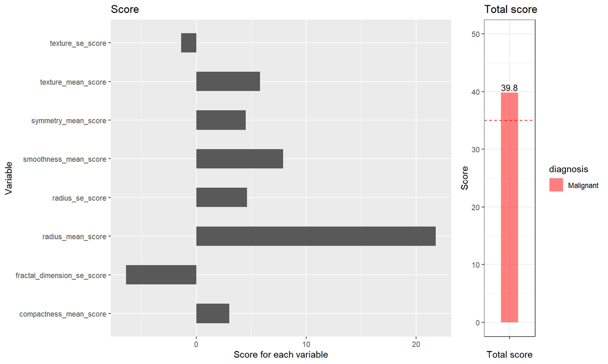

```r
# M_data # # Malignant(악성=M)인 환자데이터
use_data = M_data

result <- calculate_score_and_diagnose(use_data)

# 첫번째 그래프
# "_score"로 끝나는 변수만 선택합니다.
result_score <- dplyr::select(result, ends_with("_score"))

# 데이터를 길게 변형합니다.
result_score_long <- tidyr::pivot_longer(result_score, everything(), names_to = "variable", values_to = "value")

# 막대그래프를 그립니다.
p1 <- ggplot(result_score_long, aes(x = variable, y = value)) +
  geom_bar(stat = "identity", width = 0.5) +
  coord_flip() +
  labs(x = "Variable", y = "Score for each variable", title = "Score")

# 두번째 그래프
# "score" 열만 선택합니다.
result_score <- result$score

# 데이터 프레임을 생성합니다.
df <- data.frame(score = result_score)

# 막대그래프를 그립니다.
p2 <-  ggplot(df, aes(x = "", y = score, fill = (score > 35))) +
  geom_bar(stat = "identity", width = 0.4) +
  scale_fill_manual(values = c("TRUE" = "#FF000080", "FALSE" = "grey"), labels = c("TRUE" = "Malignant", "FALSE" = "Benign"), name = "diagnosis") +
  ylim(0,50) +
  geom_hline(yintercept = 35, linetype = "dashed", color = "red") +
  geom_text(aes(label=score), vjust=-0.3, size=3.5) +
  theme_bw() +
  labs(title = "Total score", x = "Total score", y = "Score")

# 두 그래프를 합칩니다.
grid.arrange(p1, p2, ncol=2, widths = c(3, 1))  # p1과 p2의 비율을 3:1로 설정합니다.
```

오른쪽 그래프에서 각 변수들에 대한 스코어를 총합하여 35보다 크게 나옴으로 Malignant(악성)으로 판정하는 모습을 보여줌으로서 원래 Malignant인 환자 데이터를 넣어주었을때 Malignant을 출력해줌으로 좋은 예측을 해주고 있음